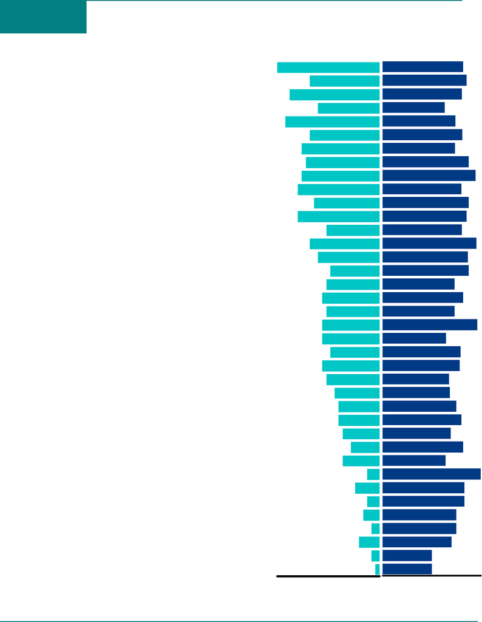

Figure AN-1

Anesthesiology

Percentage of Programs Citing Each Factor And Mean Importance Rating¹ for Each

Factor in Selecting Applicants to Interview

(N=25)

g

e Ratin

g

g

Facto

r

¹ Ratings on a scale from 1 (not at all important) to 5 (very important).

* DO seniors/graduates only.

** International Medical Graduates only.

1

2

3 4

5

4.3

4.4

4.2

3.5

4.0

4.2

3.9

4.5

4.8

4.2

4.5

4.4

4.2

4.8

4.5

4.5

3.9

4.3

3.9

4.9

3.6

4.2

4.1

3.7

3.7

4.0

4.2

3.8

4.3

3.6

5.0

4.3

4.3

4.0

4.0

3.8

3.0

3.0

100% 50% 0%

100%

68%

88%

60%

92%

68%

76%

72%

76%

80%

64%

80%

52%

68%

60%

48%

52%

56%

52%

56%

56%

48%

56%

52%

44%

40%

40%

36%

28%

36%

12%

24%

12%

16%

8%

20%

8%

4%

USMLEStep1score

Lettersofrecommendationinthespecialty

USMLEStep2CKscore

PersonalStatement

MedicalStudentPerformanceEvaluation(MSPE/Dean'sLetter)

Perceivedcommitmenttospecialty

Gradesinrequiredclerkships

Auditionelective/rotationwithinyourdepartment

AnyfailedattemptinUSMLE

Classranking/quartile

Personalpriorknowledgeoftheapplicant

Leadershipqualities

Gradesinclerkshipindesiredspecialty

Evidenceofprofessionalismandethics

Perceivedinterestinprogram

PassingUSMLEStep2CS

Otherlifeexperience

COMLEX‐USALevel1score*

AlphaOmegaAlpha(AOA)membership

AnyfailedattemptinCOMLEX‐USA*

Volunteer/extracurricularexperiences

COMLEX‐USALevel2ClinicalEvaluation(CE)score*

Consistencyofgrades

Awardsorspecialhonorsinclinicalclerkships

Graduateofhighly‐regardedmedical(MD/DO)school

Evidenceofcontinuousmedicaleducationwithoutgaps

GoldHumanismHonorSociety(GHHS)membership

Awardsorspecialhonorsinclerkshipindesiredspecialty

PassingCOMLEX‐USALevel2PerformanceEvaluation*

Demonstratedinvolvementandinterestinresearch

ApplicantwasflaggedwithMatchviolationbytheNRMP

Visastatus**

Awayrotationinyourspecialtyatanotherinstitution

Fluencyinlanguagespokenbyyourpatientpopulation

Interestinacademiccareer

Awardsorspecialhonorsinbasicsciences

USMLEStep3score

COMLEX‐USALevel3score*

NRMP Program Director Survey Results, 2020

10

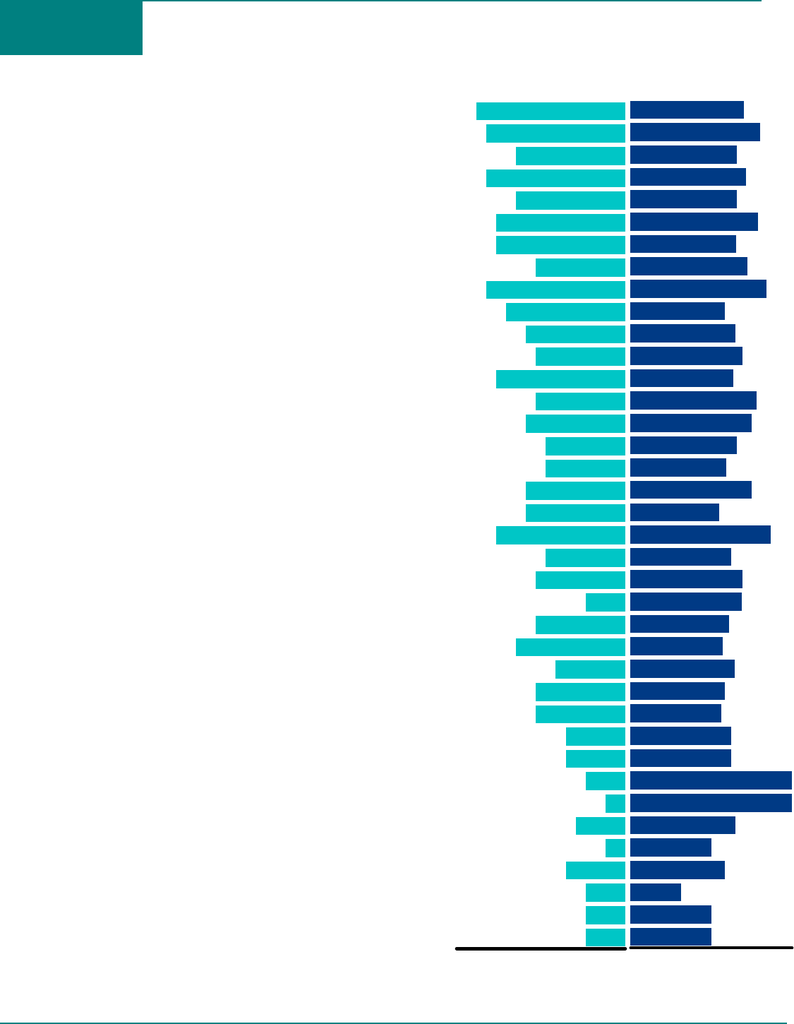

Figure CN-1

Child Neurology

Percentage of Programs Citing Each Factor And Mean Importance Rating¹ for Each

Factor in Selecting Applicants to Interview

(N=17)

Avera

g

e Ratin

g

Percent Citin

g

Facto

r

¹ Ratings on a scale from 1 (not at all important) to 5 (very important).

* DO seniors/graduates only.

** International Medical Graduates only.

1

2

3 4

5

3.8

4.2

3.6

3.9

3.6

4.2

3.6

3.9

4.4

3.3

3.6

3.8

3.5

4.1

4.0

3.6

3.4

4.0

3.2

4.5

3.5

3.8

3.8

3.4

3.3

3.6

3.3

3.3

3.5

3.5

5.0

5.0

3.6

3.0

3.3

2.3

3.0

3.0

100% 50% 0%

88%

82%

65%

82%

65%

76%

76%

53%

82%

71%

59%

53%

76%

53%

59%

47%

47%

59%

59%

76%

47%

53%

24%

53%

65%

41%

53%

53%

35%

35%

24%

12%

29%

12%

35%

24%

24%

24%

USMLEStep1score

Lettersofrecommendationinthespecialty

USMLEStep2CKscore

PersonalStatement

MedicalStudentPerformanceEvaluation(MSPE/Dean'sLetter)

Perceivedcommitmenttospecialty

Gradesinrequiredclerkships

Auditionelective/rotationwithinyourdepartment

AnyfailedattemptinUSMLE

Classranking/quartile

Personalpriorknowledgeoftheapplicant

Leadershipqualities

Gradesinclerkshipindesiredspecialty

Evidenceofprofessionalismandethics

Perceivedinterestinprogram

PassingUSMLEStep2CS

Otherlifeexperience

COMLEX‐USALevel1score*

AlphaOmegaAlpha(AOA)membership

AnyfailedattemptinCOMLEX‐USA*

Volunteer/extracurricularexperiences

COMLEX‐USALevel2ClinicalEvaluation(CE)score*

Consistencyofgrades

Awardsorspecialhonorsinclinicalclerkships

Graduateofhighly‐regardedmedical(MD/DO)school

Evidenceofcontinuousmedicaleducationwithoutgaps

GoldHumanismHonorSociety(GHHS)membership

Awardsorspecialhonorsinclerkshipindesiredspecialty

PassingCOMLEX‐USALevel2PerformanceEvaluation*

Demonstratedinvolvementandinterestinresearch

ApplicantwasflaggedwithMatchviolationbytheNRMP

Visastatus**

Awayrotationinyourspecialtyatanotherinstitution

Fluencyinlanguagespokenbyyourpatientpopulation

Interestinacademiccareer

Awardsorspecialhonorsinbasicsciences

USMLEStep3score

COMLEX‐USALevel3score*

NRMP Program Director Survey Results, 2020

17

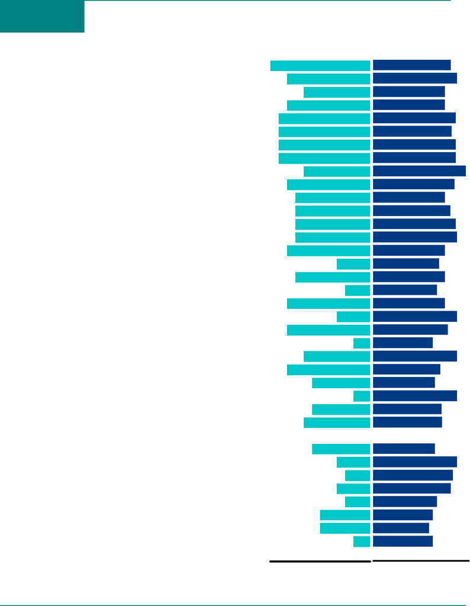

Figure D-1

Dermatology

Percentage of Programs Citing Each Factor And Mean Importance Rating¹ for Each

Factor in Selecting Applicants to Interview

(N=12)

Avera

g

e Ratin

g

Percent Citin

g

Facto

r

¹ Ratings on a scale from 1 (not at all important) to 5 (very important).

* DO seniors/graduates only.

** International Medical Graduates only.

1

2

3 4

5

4.3

4.5

4.0

4.0

4.5

4.3

4.5

4.5

4.9

4.4

4.0

4.2

4.4

4.5

4.0

3.8

4.0

3.7

4.0

4.5

4.1

3.5

4.5

3.8

3.6

4.5

3.9

3.9

3.6

4.5

4.3

4.3

3.7

3.5

3.3

3.5

100% 50% 0%

100%

83%

67%

83%

92%

92%

92%

92%

67%

83%

75%

75%

75%

75%

83%

33%

75%

25%

83%

33%

83%

17%

67%

83%

58%

17%

58%

67%

0%

58%

33%

25%

33%

25%

50%

50%

17%

0%

USMLEStep1score

Lettersofrecommendationinthespecialty

USMLEStep2CKscore

PersonalStatement

MedicalStudentPerformanceEvaluation(MSPE/Dean'sLetter)

Perceivedcommitmenttospecialty

Gradesinrequiredclerkships

Auditionelective/rotationwithinyourdepartment

AnyfailedattemptinUSMLE

Classranking/quartile

Personalpriorknowledgeoftheapplicant

Leadershipqualities

Gradesinclerkshipindesiredspecialty

Evidenceofprofessionalismandethics

Perceivedinterestinprogram

PassingUSMLEStep2CS

Otherlifeexperience

COMLEX‐USALevel1score*

AlphaOmegaAlpha(AOA)membership

AnyfailedattemptinCOMLEX‐USA*

Volunteer/extracurricularexperiences

COMLEX‐USALevel2ClinicalEvaluation(CE)score*

Consistencyofgrades

Awardsorspecialhonorsinclinicalclerkships

Graduateofhighly‐regardedmedical(MD/DO)school

Evidenceofcontinuousmedicaleducationwithoutgaps

GoldHumanismHonorSociety(GHHS)membership

Awardsorspecialhonorsinclerkshipindesiredspecialty

PassingCOMLEX‐USALevel2PerformanceEvaluation*

Demonstratedinvolvementandinterestinresearch

ApplicantwasflaggedwithMatchviolationbytheNRMP

Visastatus**

Awayrotationinyourspecialtyatanotherinstitution

Fluencyinlanguagespokenbyyourpatientpopulation

Interestinacademiccareer

Awardsorspecialhonorsinbasicsciences

USMLEStep3score

COMLEX‐USALevel3score*

NRMP Program Director Survey Results, 2020

24

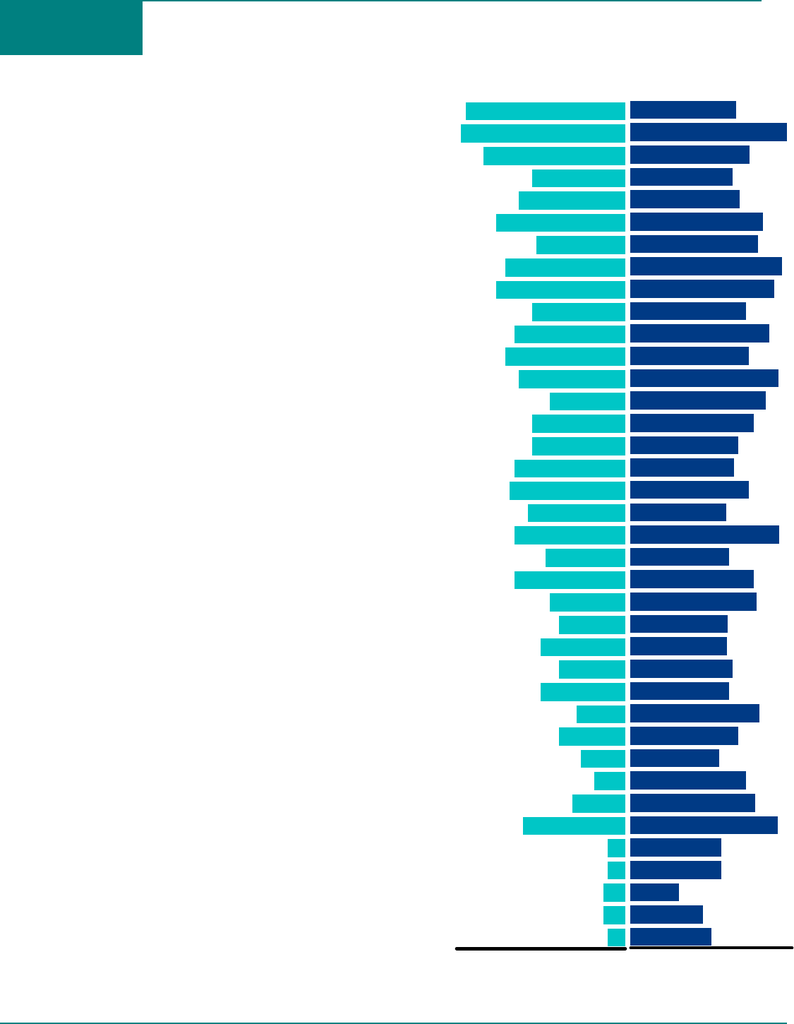

Figure EM-1

Emergency Medicine

Percentage of Programs Citing Each Factor And Mean Importance Rating¹ for Each

Factor in Selecting Applicants to Interview

(N=38)

Avera

g

e Ratin

g

Percent Citin

g

Facto

r

¹ Ratings on a scale from 1 (not at all important) to 5 (very important).

* DO seniors/graduates only.

** International Medical Graduates only.

1

2

3 4

5

3.6

4.9

3.9

3.5

3.7

4.3

4.2

4.7

4.6

3.9

4.4

3.9

4.7

4.4

4.0

3.7

3.6

3.9

3.4

4.7

3.4

4.0

4.1

3.4

3.4

3.5

3.4

4.2

3.7

3.2

3.9

4.1

4.7

3.3

3.3

2.2

2.8

3.0

100% 50% 0%

95%

97%

84%

55%

63%

76%

53%

71%

76%

55%

66%

71%

63%

45%

55%

55%

66%

68%

58%

66%

47%

66%

45%

39%

50%

39%

50%

29%

39%

26%

18%

32%

61%

11%

11%

13%

13%

11%

USMLEStep1score

Lettersofrecommendationinthespecialty

USMLEStep2CKscore

PersonalStatement

MedicalStudentPerformanceEvaluation(MSPE/Dean'sLetter)

Perceivedcommitmenttospecialty

Gradesinrequiredclerkships

Auditionelective/rotationwithinyourdepartment

AnyfailedattemptinUSMLE

Classranking/quartile

Personalpriorknowledgeoftheapplicant

Leadershipqualities

Gradesinclerkshipindesiredspecialty

Evidenceofprofessionalismandethics

Perceivedinterestinprogram

PassingUSMLEStep2CS

Otherlifeexperience

COMLEX‐USALevel1score*

AlphaOmegaAlpha(AOA)membership

AnyfailedattemptinCOMLEX‐USA*

Volunteer/extracurricularexperiences

COMLEX‐USALevel2ClinicalEvaluation(CE)score*

Consistencyofgrades

Awardsorspecialhonorsinclinicalclerkships

Graduateofhighly‐regardedmedical(MD/DO)school

Evidenceofcontinuousmedicaleducationwithoutgaps

GoldHumanismHonorSociety(GHHS)membership

Awardsorspecialhonorsinclerkshipindesiredspecialty

PassingCOMLEX‐USALevel2PerformanceEvaluation*

Demonstratedinvolvementandinterestinresearch

ApplicantwasflaggedwithMatchviolationbytheNRMP

Visastatus**

Awayrotationinyourspecialtyatanotherinstitution

Fluencyinlanguagespokenbyyourpatientpopulation

Interestinacademiccareer

Awardsorspecialhonorsinbasicsciences

USMLEStep3score

COMLEX‐USALevel3score*

NRMP Program Director Survey Results, 2020

31

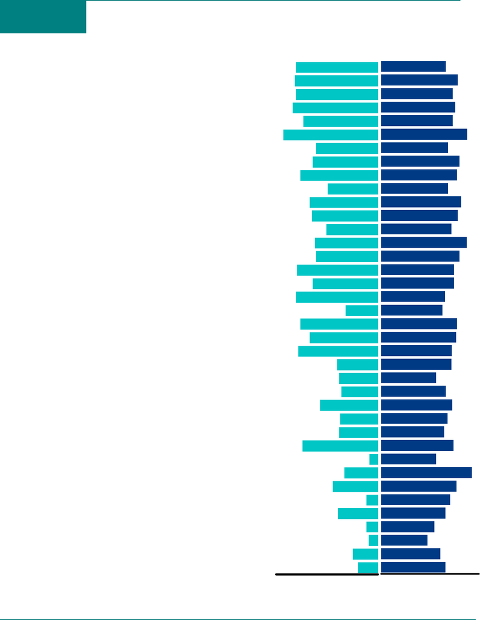

Figure FM-1

Family Medicine

Percentage of Programs Citing Each Factor And Mean Importance Rating¹ for Each

Factor in Selecting Applicants to Interview

(N=97)

Avera

g

e Ratin

g

Percent Citin

g

Facto

r

¹ Ratings on a scale from 1 (not at all important) to 5 (very important).

* DO seniors/graduates only.

** International Medical Graduates only.

1

2

3 4

5

3.6

4.1

3.9

4.0

3.9

4.5

3.7

4.2

4.1

3.7

4.3

4.1

3.9

4.5

4.2

4.0

4.0

3.6

3.5

4.1

4.1

3.9

3.9

3.2

3.7

3.9

3.7

3.6

4.0

3.3

4.7

4.1

3.8

3.6

3.2

2.9

3.4

3.6

100% 50% 0%

80%

81%

80%

84%

73%

93%

61%

64%

76%

49%

67%

65%

51%

62%

61%

79%

64%

80%

32%

76%

67%

78%

40%

38%

36%

57%

37%

38%

74%

8%

33%

44%

39%

9%

25%

20%

USMLEStep1score

Lettersofrecommendationinthespecialty

USMLEStep2CKscore

PersonalStatement

MedicalStudentPerformanceEvaluation(MSPE/Dean'sLetter)

Perceivedcommitmenttospecialty

Gradesinrequiredclerkships

Auditionelective/rotationwithinyourdepartment

AnyfailedattemptinUSMLE

Classranking/quartile

Personalpriorknowledgeoftheapplicant

Leadershipqualities

Gradesinclerkshipindesiredspecialty

Evidenceofprofessionalismandethics

Perceivedinterestinprogram

PassingUSMLEStep2CS

Otherlifeexperience

COMLEX‐USALevel1score*

AlphaOmegaAlpha(AOA)membership

AnyfailedattemptinCOMLEX‐USA*

Volunteer/extracurricularexperiences

COMLEX‐USALevel2ClinicalEvaluation(CE)score*

Consistencyofgrades

Awardsorspecialhonorsinclinicalclerkships

Graduateofhighly‐regardedmedical(MD/DO)school

Evidenceofcontinuousmedicaleducationwithoutgaps

GoldHumanismHonorSociety(GHHS)membership

Awardsorspecialhonorsinclerkshipindesiredspecialty

PassingCOMLEX‐USALevel2PerformanceEvaluation*

Demonstratedinvolvementandinterestinresearch

ApplicantwasflaggedwithMatchviolationbytheNRMP

Visastatus**

Awayrotationinyourspecialtyatanotherinstitution

Fluencyinlanguagespokenbyyourpatientpopulation

Interestinacademiccareer

Awardsorspecialhonorsinbasicsciences

USMLEStep3score

COMLEX‐USALevel3score*

NRMP Program Director Survey Results, 2020

38

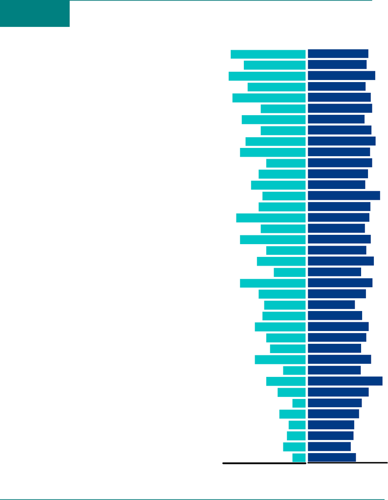

Figure IM-1

Internal Medicine

Percentage of Programs Citing Each Factor And Mean Importance Rating¹ for Each

Factor in Selecting Applicants to Interview

(N=44)

Avera

g

e Ratin

g

Percent Citin

g

Facto

r

¹ Ratings on a scale from 1 (not at all important) to 5 (very important).

* DO seniors/graduates only.

** International Medical Graduates only.

1

2

3 4

5

4.1

4.0

4.4

3.9

4.2

4.3

3.9

4.2

4.4

4.1

4.2

4.0

3.9

4.7

4.2

4.1

3.9

4.2

4.0

4.3

3.7

4.3

3.9

3.4

3.7

4.1

4.0

3.7

4.2

3.7

4.8

4.1

3.7

3.6

3.3

3.3

3.2

3.4

100% 50% 0%

91%

75%

93%

70%

89%

55%

77%

55%

73%

80%

48%

57%

66%

52%

57%

84%

55%

80%

48%

59%

39%

80%

57%

50%

52%

61%

48%

43%

61%

27%

48%

34%

16%

32%

20%

23%

27%

16%

USMLEStep1score

Lettersofrecommendationinthespecialty

USMLEStep2CKscore

PersonalStatement

MedicalStudentPerformanceEvaluation(MSPE/Dean'sLetter)

Perceivedcommitmenttospecialty

Gradesinrequiredclerkships

Auditionelective/rotationwithinyourdepartment

AnyfailedattemptinUSMLE

Classranking/quartile

Personalpriorknowledgeoftheapplicant

Leadershipqualities

Gradesinclerkshipindesiredspecialty

Evidenceofprofessionalismandethics

Perceivedinterestinprogram

PassingUSMLEStep2CS

Otherlifeexperience

COMLEX‐USALevel1score*

AlphaOmegaAlpha(AOA)membership

AnyfailedattemptinCOMLEX‐USA*

Volunteer/extracurricularexperiences

COMLEX‐USALevel2ClinicalEvaluation(CE)score*

Consistencyofgrades

Awardsorspecialhonorsinclinicalclerkships

Graduateofhighly‐regardedmedical(MD/DO)school

Evidenceofcontinuousmedicaleducationwithoutgaps

GoldHumanismHonorSociety(GHHS)membership

Awardsorspecialhonorsinclerkshipindesiredspecialty

PassingCOMLEX‐USALevel2PerformanceEvaluation*

Demonstratedinvolvementandinterestinresearch

ApplicantwasflaggedwithMatchviolationbytheNRMP

Visastatus**

Awayrotationinyourspecialtyatanotherinstitution

Fluencyinlanguagespokenbyyourpatientpopulation

Interestinacademiccareer

Awardsorspecialhonorsinbasicsciences

USMLEStep3score

COMLEX‐USALevel3score*

NRMP Program Director Survey Results, 2020

45

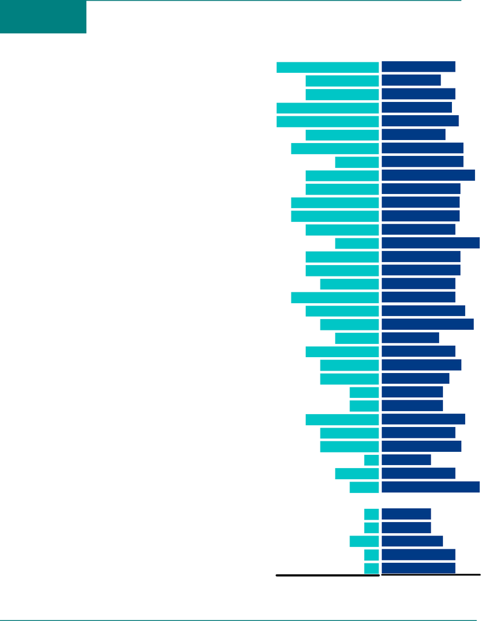

Figure IMP-1

Internal Medicine/Pediatrics

Percentage of Programs Citing Each Factor And Mean Importance Rating¹ for Each

Factor in Selecting Applicants to Interview

(N=7)

Avera

g

e Ratin

g

Percent Citin

g

Facto

r

¹ Ratings on a scale from 1 (not at all important) to 5 (very important).

* DO seniors/graduates only.

** International Medical Graduates only.

1

2

3 4

5

4.0

3.4

4.0

3.9

4.1

3.6

4.3

4.3

4.8

4.2

4.2

4.2

4.0

5.0

4.2

4.2

4.0

4.0

4.4

4.8

3.3

4.0

4.3

3.8

3.5

3.5

4.4

4.0

4.3

3.0

4.0

5.0

3.0

3.0

3.5

4.0

4.0

100% 50% 0%

100%

71%

71%

100%

100%

71%

86%

43%

71%

71%

86%

86%

71%

43%

71%

71%

57%

86%

71%

57%

43%

71%

57%

57%

29%

29%

71%

57%

57%

14%

43%

29%

0%

14%

14%

29%

14%

14%

USMLEStep1score

Lettersofrecommendationinthespecialty

USMLEStep2CKscore

PersonalStatement

MedicalStudentPerformanceEvaluation(MSPE/Dean'sLetter)

Perceivedcommitmenttospecialty

Gradesinrequiredclerkships

Auditionelective/rotationwithinyourdepartment

AnyfailedattemptinUSMLE

Classranking/quartile

Personalpriorknowledgeoftheapplicant

Leadershipqualities

Gradesinclerkshipindesiredspecialty

Evidenceofprofessionalismandethics

Perceivedinterestinprogram

PassingUSMLEStep2CS

Otherlifeexperience

COMLEX‐USALevel1score*

AlphaOmegaAlpha(AOA)membership

AnyfailedattemptinCOMLEX‐USA*

Volunteer/extracurricularexperiences

COMLEX‐USALevel2ClinicalEvaluation(CE)score*

Consistencyofgrades

Awardsorspecialhonorsinclinicalclerkships

Graduateofhighly‐regardedmedical(MD/DO)school

Evidenceofcontinuousmedicaleducationwithoutgaps

GoldHumanismHonorSociety(GHHS)membership

Awardsorspecialhonorsinclerkshipindesiredspecialty

PassingCOMLEX‐USALevel2PerformanceEvaluation*

Demonstratedinvolvementandinterestinresearch

ApplicantwasflaggedwithMatchviolationbytheNRMP

Visastatus**

Awayrotationinyourspecialtyatanotherinstitution

Fluencyinlanguagespokenbyyourpatientpopulation

Interestinacademiccareer

Awardsorspecialhonorsinbasicsciences

USMLEStep3score

COMLEX‐USALevel3score*

NRMP Program Director Survey Results, 2020

52

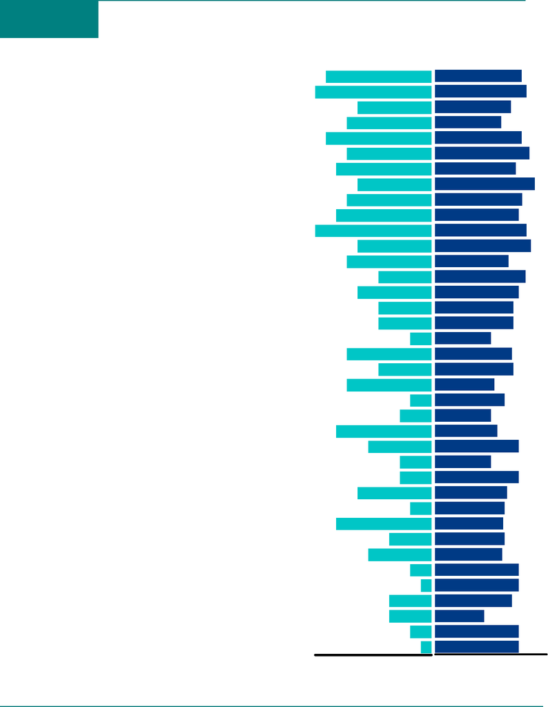

Figure IR-1

Interventional Radiology

Percentage of Programs Citing Each Factor And Mean Importance Rating¹ for Each

Factor in Selecting Applicants to Interview

(N=11)

Avera

g

e Ratin

g

Percent Citin

g

Facto

r

¹ Ratings on a scale from 1 (not at all important) to 5 (very important).

* DO seniors/graduates only.

** International Medical Graduates only.

1

2

3 4

5

4.1

4.3

3.7

3.4

4.1

4.4

3.9

4.6

4.1

4.0

4.3

4.4

3.6

4.3

4.0

3.8

3.8

3.0

3.8

3.8

3.1

3.5

3.0

3.2

4.0

3.0

4.0

3.6

3.5

3.4

3.5

3.4

4.0

4.0

3.8

2.8

4.0

4.0

100% 50% 0%

91%

100%

64%

73%

91%

73%

82%

64%

73%

82%

100%

64%

73%

45%

64%

45%

45%

18%

73%

45%

73%

18%

27%

82%

55%

27%

27%

64%

18%

82%

36%

55%

18%

9%

36%

36%

18%

9%

USMLEStep1score

Lettersofrecommendationinthespecialty

USMLEStep2CKscore

PersonalStatement

MedicalStudentPerformanceEvaluation(MSPE/Dean'sLetter)

Perceivedcommitmenttospecialty

Gradesinrequiredclerkships

Auditionelective/rotationwithinyourdepartment

AnyfailedattemptinUSMLE

Classranking/quartile

Personalpriorknowledgeoftheapplicant

Leadershipqualities

Gradesinclerkshipindesiredspecialty

Evidenceofprofessionalismandethics

Perceivedinterestinprogram

PassingUSMLEStep2CS

Otherlifeexperience

COMLEX‐USALevel1score*

AlphaOmegaAlpha(AOA)membership

AnyfailedattemptinCOMLEX‐USA*

Volunteer/extracurricularexperiences

COMLEX‐USALevel2ClinicalEvaluation(CE)score*

Consistencyofgrades

Awardsorspecialhonorsinclinicalclerkships

Graduateofhighly‐regardedmedical(MD/DO)school

Evidenceofcontinuousmedicaleducationwithoutgaps

GoldHumanismHonorSociety(GHHS)membership

Awardsorspecialhonorsinclerkshipindesiredspecialty

PassingCOMLEX‐USALevel2PerformanceEvaluation*

Demonstratedinvolvementandinterestinresearch

ApplicantwasflaggedwithMatchviolationbytheNRMP

Visastatus**

Awayrotationinyourspecialtyatanotherinstitution

Fluencyinlanguagespokenbyyourpatientpopulation

Interestinacademiccareer

Awardsorspecialhonorsinbasicsciences

USMLEStep3score

COMLEX‐USALevel3score*

NRMP Program Director Survey Results, 2020

59

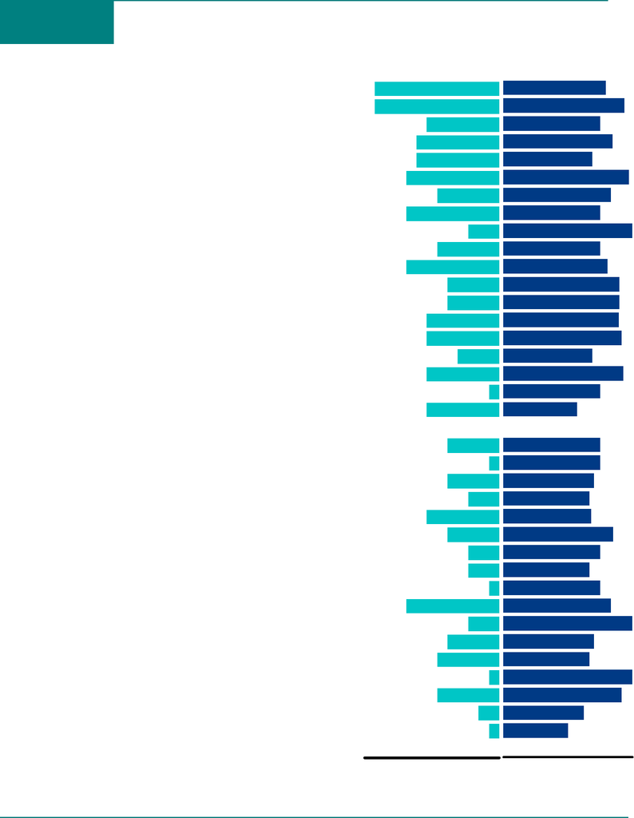

Figure NS-1

Neurological Surgery

Percentage of Programs Citing Each Factor And Mean Importance Rating¹ for Each

Factor in Selecting Applicants to Interview

(N=13)

Avera

g

e Ratin

g

Percent Citin

g

Facto

r

¹ Ratings on a scale from 1 (not at all important) to 5 (very important).

* DO seniors/graduates only.

** International Medical Graduates only.

1

2

3 4

5

4.2

4.8

4.0

4.4

3.8

4.9

4.3

4.0

5.0

4.0

4.2

4.6

4.6

4.6

4.7

3.8

4.7

4.0

3.3

4.0

4.0

3.8

3.7

3.7

4.4

4.0

3.7

4.0

4.3

5.0

3.8

3.7

5.0

4.7

3.5

3.0

100% 50% 0%

92%

92%

54%

62%

62%

69%

46%

69%

23%

46%

69%

38%

38%

54%

54%

31%

54%

8%

54%

0%

38%

8%

38%

23%

54%

38%

23%

23%

8%

69%

23%

38%

46%

8%

46%

15%

8%

0%

USMLEStep1score

Lettersofrecommendationinthespecialty

USMLEStep2CKscore

PersonalStatement

MedicalStudentPerformanceEvaluation(MSPE/Dean'sLetter)

Perceivedcommitmenttospecialty

Gradesinrequiredclerkships

Auditionelective/rotationwithinyourdepartment

AnyfailedattemptinUSMLE

Classranking/quartile

Personalpriorknowledgeoftheapplicant

Leadershipqualities

Gradesinclerkshipindesiredspecialty

Evidenceofprofessionalismandethics

Perceivedinterestinprogram

PassingUSMLEStep2CS

Otherlifeexperience

COMLEX‐USALevel1score*

AlphaOmegaAlpha(AOA)membership

AnyfailedattemptinCOMLEX‐USA*

Volunteer/extracurricularexperiences

COMLEX‐USALevel2ClinicalEvaluation(CE)score*

Consistencyofgrades

Awardsorspecialhonorsinclinicalclerkships

Graduateofhighly‐regardedmedical(MD/DO)school

Evidenceofcontinuousmedicaleducationwithoutgaps

GoldHumanismHonorSociety(GHHS)membership

Awardsorspecialhonorsinclerkshipindesiredspecialty

PassingCOMLEX‐USALevel2PerformanceEvaluation*

Demonstratedinvolvementandinterestinresearch

ApplicantwasflaggedwithMatchviolationbytheNRMP

Visastatus**

Awayrotationinyourspecialtyatanotherinstitution

Fluencyinlanguagespokenbyyourpatientpopulation

Interestinacademiccareer

Awardsorspecialhonorsinbasicsciences

USMLEStep3score

COMLEX‐USALevel3score*

NRMP Program Director Survey Results, 2020

66

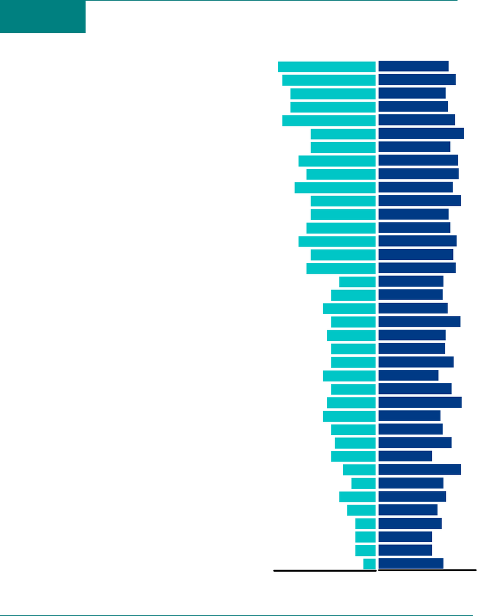

Figure N-1

Neurology

Percentage of Programs Citing Each Factor And Mean Importance Rating¹ for Each

Factor in Selecting Applicants to Interview

(N=25)

Avera

g

e Ratin

g

Percent Citin

g

Facto

r

¹ Ratings on a scale from 1 (not at all important) to 5 (very important).

* DO seniors/graduates only.

** International Medical Graduates only.

1

2

3 4

5

3.9

4.2

3.8

3.9

4.1

4.5

3.9

4.3

4.3

4.0

4.4

3.9

3.9

4.2

4.1

4.2

3.7

3.6

3.8

4.4

3.8

3.7

4.1

3.5

4.0

4.4

3.5

3.6

4.0

3.2

4.4

3.7

3.8

3.4

3.6

3.2

3.2

3.7

100% 50% 0%

96%

92%

84%

84%

92%

64%

64%

76%

68%

80%

64%

64%

68%

76%

64%

68%

36%

44%

52%

44%

48%

44%

44%

52%

44%

48%

52%

44%

40%

44%

32%

24%

36%

28%

20%

20%

20%

12%

USMLEStep1score

Lettersofrecommendationinthespecialty

USMLEStep2CKscore

PersonalStatement

MedicalStudentPerformanceEvaluation(MSPE/Dean'sLetter)

Perceivedcommitmenttospecialty

Gradesinrequiredclerkships

Auditionelective/rotationwithinyourdepartment

AnyfailedattemptinUSMLE

Classranking/quartile

Personalpriorknowledgeoftheapplicant

Leadershipqualities

Gradesinclerkshipindesiredspecialty

Evidenceofprofessionalismandethics

Perceivedinterestinprogram

PassingUSMLEStep2CS

Otherlifeexperience

COMLEX‐USALevel1score*

AlphaOmegaAlpha(AOA)membership

AnyfailedattemptinCOMLEX‐USA*

Volunteer/extracurricularexperiences

COMLEX‐USALevel2ClinicalEvaluation(CE)score*

Consistencyofgrades

Awardsorspecialhonorsinclinicalclerkships

Graduateofhighly‐regardedmedical(MD/DO)school

Evidenceofcontinuousmedicaleducationwithoutgaps

GoldHumanismHonorSociety(GHHS)membership

Awardsorspecialhonorsinclerkshipindesiredspecialty

PassingCOMLEX‐USALevel2PerformanceEvaluation*

Demonstratedinvolvementandinterestinresearch

ApplicantwasflaggedwithMatchviolationbytheNRMP

Visastatus**

Awayrotationinyourspecialtyatanotherinstitution

Fluencyinlanguagespokenbyyourpatientpopulation

Interestinacademiccareer

Awardsorspecialhonorsinbasicsciences

USMLEStep3score

COMLEX‐USALevel3score*

NRMP Program Director Survey Results, 2020

73

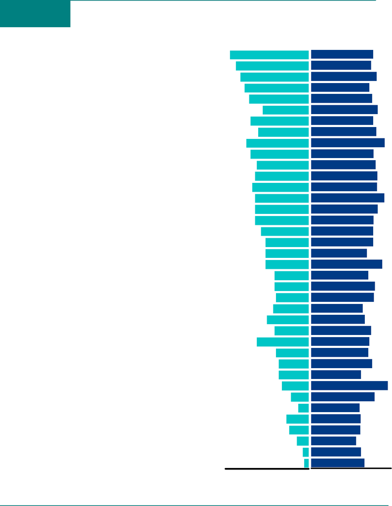

Figure OG-1

Obstetrics and Gynecology

Percentage of Programs Citing Each Factor And Mean Importance Rating¹ for Each

Factor in Selecting Applicants to Interview

(N=56)

Avera

g

e Ratin

g

Percent Citin

g

Facto

r

¹ Ratings on a scale from 1 (not at all important) to 5 (very important).

* DO seniors/graduates only.

** International Medical Graduates only.

1

2

3 4

5

4.1

4.0

4.3

3.9

4.1

4.3

4.1

4.3

4.7

4.1

4.2

4.3

4.3

4.7

4.3

4.1

4.1

4.1

3.8

4.6

3.9

4.2

4.1

3.6

3.7

4.0

3.9

3.9

4.1

3.5

4.8

4.2

3.4

3.5

3.5

3.3

3.5

3.7

100% 50% 0%

95%

88%

82%

77%

71%

55%

70%

61%

75%

70%

63%

64%

68%

64%

64%

64%

57%

52%

52%

52%

41%

41%

39%

43%

50%

41%

63%

39%

36%

36%

32%

21%

13%

27%

23%

14%

7%

5%

USMLEStep1score

Lettersofrecommendationinthespecialty

USMLEStep2CKscore

PersonalStatement

MedicalStudentPerformanceEvaluation(MSPE/Dean'sLetter)

Perceivedcommitmenttospecialty

Gradesinrequiredclerkships

Auditionelective/rotationwithinyourdepartment

AnyfailedattemptinUSMLE

Classranking/quartile

Personalpriorknowledgeoftheapplicant

Leadershipqualities

Gradesinclerkshipindesiredspecialty

Evidenceofprofessionalismandethics

Perceivedinterestinprogram

PassingUSMLEStep2CS

Otherlifeexperience

COMLEX‐USALevel1score*

AlphaOmegaAlpha(AOA)membership

AnyfailedattemptinCOMLEX‐USA*

Volunteer/extracurricularexperiences

COMLEX‐USALevel2ClinicalEvaluation(CE)score*

Consistencyofgrades

Awardsorspecialhonorsinclinicalclerkships

Graduateofhighly‐regardedmedical(MD/DO)school

Evidenceofcontinuousmedicaleducationwithoutgaps

GoldHumanismHonorSociety(GHHS)membership

Awardsorspecialhonorsinclerkshipindesiredspecialty

PassingCOMLEX‐USALevel2PerformanceEvaluation*

Demonstratedinvolvementandinterestinresearch

ApplicantwasflaggedwithMatchviolationbytheNRMP

Visastatus**

Awayrotationinyourspecialtyatanotherinstitution

Fluencyinlanguagespokenbyyourpatientpopulation

Interestinacademiccareer

Awardsorspecialhonorsinbasicsciences

USMLEStep3score

COMLEX‐USALevel3score*

NRMP Program Director Survey Results, 2020

80

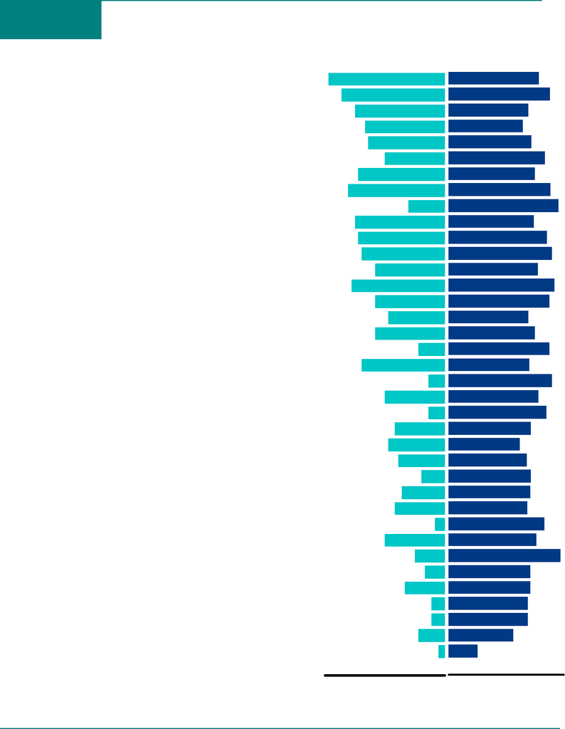

Figure OS-1

Orthopaedic Surgery

Percentage of Programs Citing Each Factor And Mean Importance Rating¹ for Each

Factor in Selecting Applicants to Interview

(N=36)

Avera

g

e Ratin

g

Percent Citin

g

Facto

r

¹ Ratings on a scale from 1 (not at all important) to 5 (very important).

* DO seniors/graduates only.

** International Medical Graduates only.

1

2

3 4

5

4.1

4.5

3.8

3.6

3.9

4.4

4.0

4.5

4.8

4.0

4.4

4.6

4.1

4.7

4.5

3.8

4.0

4.5

3.8

4.6

4.1

4.4

3.9

3.5

3.7

3.9

3.8

3.7

4.3

4.1

4.9

3.8

3.8

3.8

3.8

3.3

2.0

100% 50% 0%

97%

86%

75%

67%

64%

50%

72%

81%

31%

75%

72%

69%

58%

78%

58%

47%

58%

22%

69%

14%

50%

14%

42%

47%

39%

19%

36%

42%

8%

50%

25%

17%

33%

11%

11%

22%

6%

0%

USMLEStep1score

Lettersofrecommendationinthespecialty

USMLEStep2CKscore

PersonalStatement

MedicalStudentPerformanceEvaluation(MSPE/Dean'sLetter)

Perceivedcommitmenttospecialty

Gradesinrequiredclerkships

Auditionelective/rotationwithinyourdepartment

AnyfailedattemptinUSMLE

Classranking/quartile

Personalpriorknowledgeoftheapplicant

Leadershipqualities

Gradesinclerkshipindesiredspecialty

Evidenceofprofessionalismandethics

Perceivedinterestinprogram

PassingUSMLEStep2CS

Otherlifeexperience

COMLEX‐USALevel1score*

AlphaOmegaAlpha(AOA)membership

AnyfailedattemptinCOMLEX‐USA*

Volunteer/extracurricularexperiences

COMLEX‐USALevel2ClinicalEvaluation(CE)score*

Consistencyofgrades

Awardsorspecialhonorsinclinicalclerkships

Graduateofhighly‐regardedmedical(MD/DO)school

Evidenceofcontinuousmedicaleducationwithoutgaps

GoldHumanismHonorSociety(GHHS)membership

Awardsorspecialhonorsinclerkshipindesiredspecialty

PassingCOMLEX‐USALevel2PerformanceEvaluation*

Demonstratedinvolvementandinterestinresearch

ApplicantwasflaggedwithMatchviolationbytheNRMP

Visastatus**

Awayrotationinyourspecialtyatanotherinstitution

Fluencyinlanguagespokenbyyourpatientpopulation

Interestinacademiccareer

Awardsorspecialhonorsinbasicsciences

USMLEStep3score

COMLEX‐USALevel3score*

NRMP Program Director Survey Results, 2020

87

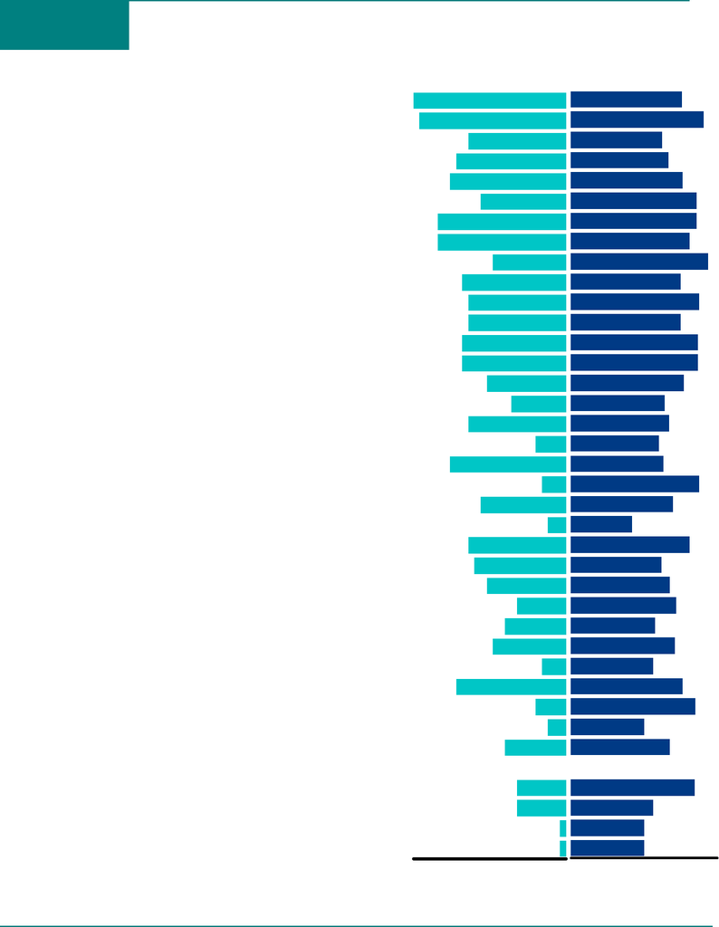

Figure O-1

Otolaryngology

Percentage of Programs Citing Each Factor And Mean Importance Rating¹ for Each

Factor in Selecting Applicants to Interview

(N=25)

Avera

g

e Ratin

g

Percent Citin

g

Facto

r

¹ Ratings on a scale from 1 (not at all important) to 5 (very important).

* DO seniors/graduates only.

** International Medical Graduates only.

1

2

3 4

5

4.0

4.6

3.5

3.7

4.1

4.4

4.4

4.2

4.8

4.0

4.5

4.0

4.5

4.5

4.1

3.6

3.7

3.4

3.5

4.5

3.8

2.7

4.3

3.5

3.7

3.9

3.3

3.8

3.3

4.1

4.4

3.0

3.7

4.4

3.3

3.0

3.0

100% 50% 0%

100%

96%

64%

72%

76%

56%

84%

84%

48%

68%

64%

64%

68%

68%

52%

36%

64%

20%

76%

16%

56%

12%

64%

60%

52%

32%

40%

48%

16%

72%

20%

12%

40%

0%

32%

32%

4%

4%

USMLEStep1score

Lettersofrecommendationinthespecialty

USMLEStep2CKscore

PersonalStatement

MedicalStudentPerformanceEvaluation(MSPE/Dean'sLetter)

Perceivedcommitmenttospecialty

Gradesinrequiredclerkships

Auditionelective/rotationwithinyourdepartment

AnyfailedattemptinUSMLE

Classranking/quartile

Personalpriorknowledgeoftheapplicant

Leadershipqualities

Gradesinclerkshipindesiredspecialty

Evidenceofprofessionalismandethics

Perceivedinterestinprogram

PassingUSMLEStep2CS

Otherlifeexperience

COMLEX‐USALevel1score*

AlphaOmegaAlpha(AOA)membership

AnyfailedattemptinCOMLEX‐USA*

Volunteer/extracurricularexperiences

COMLEX‐USALevel2ClinicalEvaluation(CE)score*

Consistencyofgrades

Awardsorspecialhonorsinclinicalclerkships

Graduateofhighly‐regardedmedical(MD/DO)school

Evidenceofcontinuousmedicaleducationwithoutgaps

GoldHumanismHonorSociety(GHHS)membership

Awardsorspecialhonorsinclerkshipindesiredspecialty

PassingCOMLEX‐USALevel2PerformanceEvaluation*

Demonstratedinvolvementandinterestinresearch

ApplicantwasflaggedwithMatchviolationbytheNRMP

Visastatus**

Awayrotationinyourspecialtyatanotherinstitution

Fluencyinlanguagespokenbyyourpatientpopulation

Interestinacademiccareer

Awardsorspecialhonorsinbasicsciences

USMLEStep3score

COMLEX‐USALevel3score*

NRMP Program Director Survey Results, 2020

94

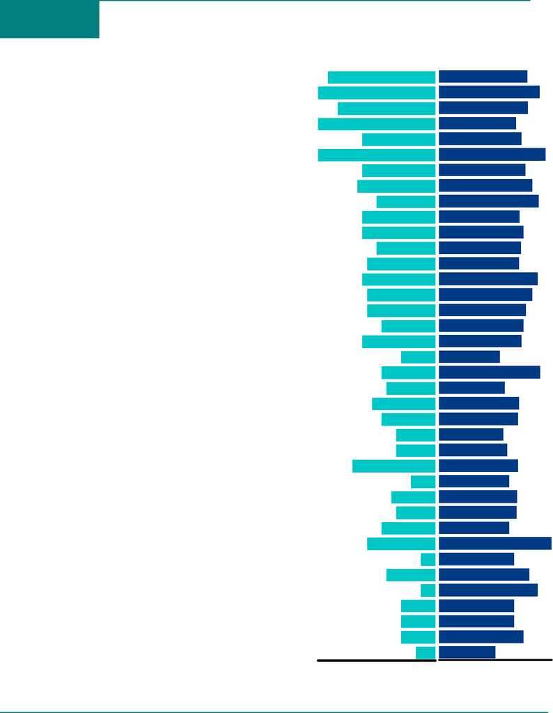

Figure PA-1

Pathology

Percentage of Programs Citing Each Factor And Mean Importance Rating¹ for Each

Factor in Selecting Applicants to Interview

(N=24)

Avera

g

e Ratin

g

Percent Citin

g

Facto

r

¹ Ratings on a scale from 1 (not at all important) to 5 (very important).

* DO seniors/graduates only.

** International Medical Graduates only.

1

2

3 4

5

4.1

4.6

4.2

3.7

3.9

4.8

4.1

4.3

4.5

3.9

4.0

3.9

3.8

4.5

4.3

4.1

4.0

3.9

3.2

4.6

3.3

3.8

3.8

3.3

3.4

3.8

3.5

3.8

3.8

3.5

5.0

3.7

4.2

4.5

3.7

3.7

4.0

3.0

100% 50% 0%

92%

100%

83%

100%

63%

100%

63%

67%